# Exploring data sets for modeling

```r
IV <- readRDS(here("output","independentVars.rds")) %>%
  st_as_sf()
DV <- readRDS(here("output","dependentVar.rds"))

nottypes <- c("wildlings","age","bio01","bio19","seeds.ExP","seeds.WALD","relelev")
```

Only plotting with randomseed == 1. Other randomseeds will have slightly different distributions of wildlings across height classes (but the same total number of wildlings).

```r
DV <- filter(DV, randomseed == 1)
```

Also, only examining independent variables once — not separately for each height class — as they remain identical.

# Larix

```r
IVi <- filter(IV, species == "Larix") %>%
  remove_zero_cols()
DVi <- filter(DV, species == "Larix")
dat <- DVi %>%
  group_split(hgtclass) %>%
  map(~ add_wildlings(IVi, .) %>%
        st_drop_geometry())
```

‘wildlings’ below are those in height class 2.

```
## temporary images written to 'C:\tmp'
```

### Data Frame Summary

#### dat

**Dimensions:** 32958 x 32  
**Duplicates:** 0

No

Variable

Stats / Values

Freqs (% of Valid)

Graph

Missing

1

species  
[character]

1. Larix

32958 (100.0%)

0  
(0.0%)

2

wildlings  
[numeric]

Mean (sd) : 0.1 (0.7)  
min < med < max:  
0 < 0 < 29  
IQR (CV) : 0 (9)

23 distinct values

0  
(0.0%)

3

locality  
[character]

1. stordalslia  
2. roeynaasen  
3. haalandsbotn  
4. myrvoll  
5. hoegaas  
6. engjane  
7. hyljafjellet  
8. toegjefjellet  
9. voren  
10. anisdal  
[ 5 others ]

2461 ( 7.5%)  
2383 ( 7.2%)  
2363 ( 7.2%)  
2338 ( 7.1%)  
2336 ( 7.1%)  
2329 ( 7.1%)  
2325 ( 7.1%)  
2282 ( 6.9%)  
2208 ( 6.7%)  
2202 ( 6.7%)  
9731 (29.5%)

0  
(0.0%)

4

age  
[numeric]

Mean (sd) : 52.2 (18.8)  
min < med < max:  
16.5 < 57.5 < 84  
IQR (CV) : 17 (0.4)

12 distinct values

0  
(0.0%)

5

bio01  
[numeric]

Mean (sd) : 66.1 (8.6)  
min < med < max:  
46.2 < 68.8 < 79.9  
IQR (CV) : 13.7 (0.1)

15 distinct values

0  
(0.0%)

6

bio19  
[numeric]

Mean (sd) : 402.5 (49.8)  
min < med < max:  
330 < 394 < 522  
IQR (CV) : 15 (0.1)

12 distinct values

0  
(0.0%)

7

seeds.ExP  
[numeric]

Mean (sd) : 0 (0)  
min < med < max:  
0 < 0 < 0  
IQR (CV) : 0 (8.1)

32958 distinct values

0  
(0.0%)

8

seeds.WALD  
[numeric]

Mean (sd) : 0 (0)  
min < med < max:  
0 < 0 < 0  
IQR (CV) : 0 (2.4)

32940 distinct values

0  
(0.0%)

9

relelev  
[numeric]

Mean (sd) : -14.7 (32.9)  
min < med < max:  
-184.9 < -13.2 < 155.8  
IQR (CV) : 34.2 (-2.2)

32883 distinct values

0  
(0.0%)

10

plantation forest  
[numeric]

Mean (sd) : 0 (0.1)  
min < med < max:  
0 < 0 < 1  
IQR (CV) : 0 (6.6)

583 distinct values

0  
(0.0%)

11

T44  
[numeric]

Mean (sd) : 0.1 (0.3)  
min < med < max:  
0 < 0 < 1  
IQR (CV) : 0 (3.4)

473 distinct values

0  
(0.0%)

12

artificial  
[numeric]

Mean (sd) : 0.1 (0.2)  
min < med < max:  
0 < 0 < 1  
IQR (CV) : 0 (3.5)

853 distinct values

0  
(0.0%)

13

T45  
[numeric]

Mean (sd) : 0.3 (0.4)  
min < med < max:  
0 < 0 < 1  
IQR (CV) : 0.9 (1.5)

915 distinct values

0  
(0.0%)

14

T32  
[numeric]

Mean (sd) : 0.1 (0.2)  
min < med < max:  
0 < 0 < 1  
IQR (CV) : 0 (3.1)

783 distinct values

0  
(0.0%)

15

V9  
[numeric]

Mean (sd) : 0 (0.2)  
min < med < max:  
0 < 0 < 1  
IQR (CV) : 0 (5.5)

495 distinct values

0  
(0.0%)

16

T34  
[numeric]

Mean (sd) : 0.2 (0.3)  
min < med < max:  
0 < 0 < 1  
IQR (CV) : 0 (2.1)

871 distinct values

0  
(0.0%)

17

V12  
[numeric]

Mean (sd) : 0 (0)  
min < med < max:  
0 < 0 < 1  
IQR (CV) : 0 (19.2)

78 distinct values

0  
(0.0%)

18

V1  
[numeric]

Mean (sd) : 0 (0.1)  
min < med < max:  
0 < 0 < 1  
IQR (CV) : 0 (4.7)

381 distinct values

0  
(0.0%)

19

T13  
[numeric]

Mean (sd) : 0 (0)  
min < med < max:  
0 < 0 < 1  
IQR (CV) : 0 (28)

56 distinct values

0  
(0.0%)

20

T4  
[numeric]

Mean (sd) : 0.2 (0.4)  
min < med < max:  
0 < 0 < 1  
IQR (CV) : 0 (2.1)

760 distinct values

0  
(0.0%)

21

T41  
[numeric]

Mean (sd) : 0 (0.2)  
min < med < max:  
0 < 0 < 1  
IQR (CV) : 0 (5.6)

337 distinct values

0  
(0.0%)

22

T1  
[numeric]

Mean (sd) : 0 (0.1)  
min < med < max:  
0 < 0 < 1  
IQR (CV) : 0 (4.2)

374 distinct values

0  
(0.0%)

23

V2  
[numeric]

Mean (sd) : 0 (0)  
min < med < max:  
0 < 0 < 1  
IQR (CV) : 0 (25.3)

42 distinct values

0  
(0.0%)

24

T2  
[numeric]

Mean (sd) : 0 (0)  
min < med < max:  
0 < 0 < 0.6  
IQR (CV) : 0 (30.4)

26 distinct values

0  
(0.0%)

25

T40  
[numeric]

Mean (sd) : 0 (0)  
min < med < max:  
0 < 0 < 1  
IQR (CV) : 0 (33.2)

46 distinct values

0  
(0.0%)

26

T42  
[numeric]

Mean (sd) : 0 (0)  
min < med < max:  
0 < 0 < 1  
IQR (CV) : 0 (21.1)

101 distinct values

0  
(0.0%)

27

V10  
[numeric]

Mean (sd) : 0 (0.1)  
min < med < max:  
0 < 0 < 1  
IQR (CV) : 0 (12.9)

128 distinct values

0  
(0.0%)

28

T30  
[numeric]

Mean (sd) : 0 (0)  
min < med < max:  
0 < 0 < 1  
IQR (CV) : 0 (31.3)

42 distinct values

0  
(0.0%)

29

T18  
[numeric]

Mean (sd) : 0 (0)  
min < med < max:  
0 < 0 < 1  
IQR (CV) : 0 (65.8)

8 distinct values

[figure not shown]

0  
(0.0%)

30

T27  
[numeric]

Mean (sd) : 0 (0)  
min < med < max:  
0 < 0 < 1  
IQR (CV) : 0 (37.6)

36 distinct values

0  
(0.0%)

31

T17  
[numeric]

Mean (sd) : 0 (0)  
min < med < max:  
0 < 0 < 1  
IQR (CV) : 0 (37.3)

26 distinct values

0  
(0.0%)

32

T29  
[numeric]

Mean (sd) : 0 (0)  
min < med < max:  
0 < 0 < 0.9  
IQR (CV) : 0 (38.6)

34 distinct values

0  
(0.0%)

‘wildlings’ by height class and locality.

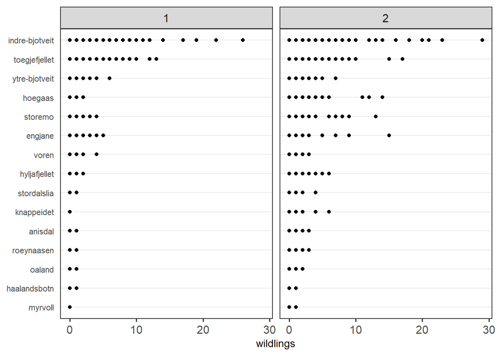

```r
bind_rows(dat, .id = "hgtclass") %>%
  ggplot(aes(wildlings, fct_reorder(locality, wildlings, mean))) +
         geom_point() + theme_dotplot + facet_grid(cols = vars(hgtclass))
```

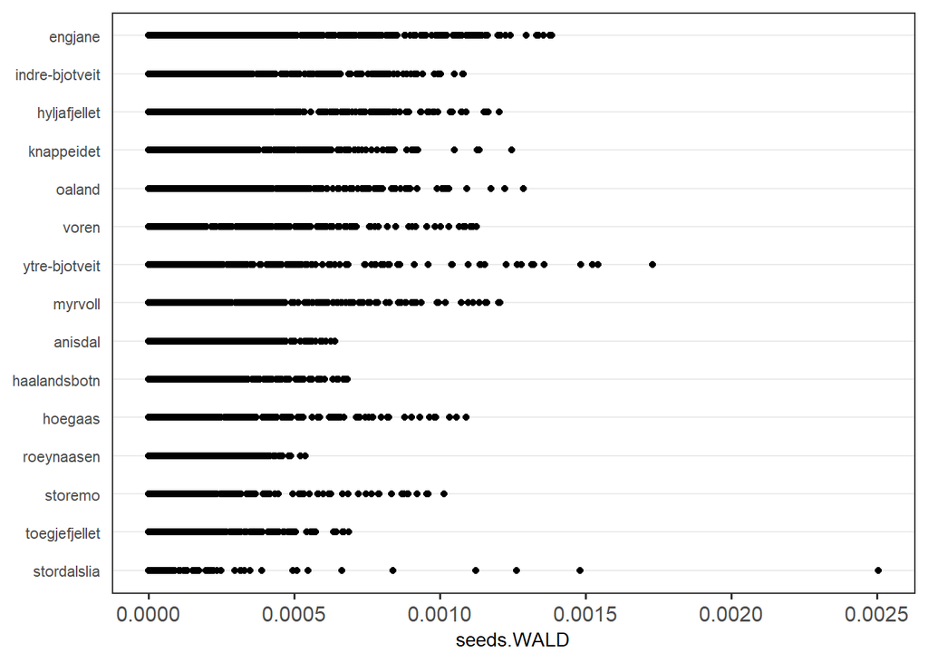

```r
ggplot(dat[[2]], aes(seeds.WALD, fct_reorder(locality, seeds.WALD, mean))) + geom_point() + theme_dotplot
```

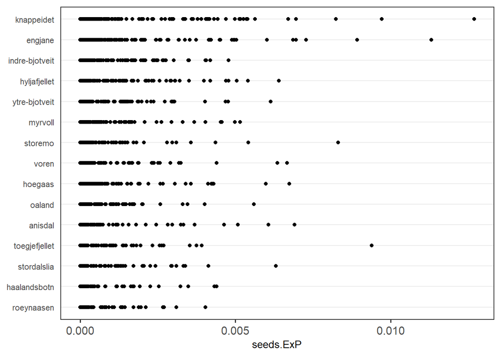

```r
ggplot(dat[[2]], aes(seeds.ExP, fct_reorder(locality, seeds.ExP, mean))) + geom_point() + theme_dotplot
```

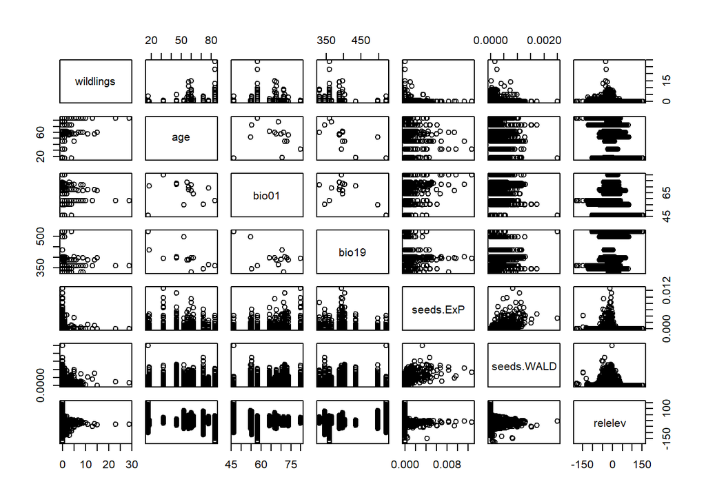

```r
pairs(dat[[2]][sample(nrow(dat[[2]]), 1e4), nottypes])
```

# P.abies

```r
IVi <- filter(IV, species == "P.abies") %>%
  remove_zero_cols()
DVi <- filter(DV, species == "P.abies")
dat <- DVi %>%
  group_split(hgtclass) %>%
  map(~ add_wildlings(IVi, .) %>%
        st_drop_geometry())
```

‘wildlings’ below are those in height class 2.

```
## temporary images written to 'C:\tmp'
```

### Data Frame Summary

#### dat

**Dimensions:** 40485 x 33  
**Duplicates:** 0

| No | Variable | Stats / Values | Freqs (% of Valid) | Graph | Missing |
| --- | --- | --- | --- | --- | --- |
| 1 | species [character] | 1. P.abies | 40485 (100.0%) |  | 0 (0.0%) |
| 2 | wildlings [numeric] | Mean (sd) : 0 (0.3) min < med < max: 0 < 0 < 13 IQR (CV) : 0 (9.3) | 14 distinct values |  | 0 (0.0%) |
| 3 | locality [character] | 1. varland 2. mysingveien 3. boerve 4. bondhusdalen 5. tennes 6. myrvoll 7. hjelmtveit 8. myklebostad 9. skare 10. saeboe [ 9 others ] | 2416 ( 6.0%) 2389 ( 5.9%) 2377 ( 5.9%) 2361 ( 5.8%) 2345 ( 5.8%) 2325 ( 5.7%) 2316 ( 5.7%) 2291 ( 5.7%) 2265 ( 5.6%) 2259 ( 5.6%) 17141 (42.3%) |  | 0 (0.0%) |
| 4 | age [numeric] | Mean (sd) : 62.2 (16.3) min < med < max: 36.5 < 57 < 101 IQR (CV) : 14 (0.3) | 16 distinct values |  | 0 (0.0%) |
| 5 | bio01 [numeric] | Mean (sd) : 58.7 (13.1) min < med < max: 18.7 < 63.4 < 71.5 IQR (CV) : 19.2 (0.2) | 19 distinct values |  | 0 (0.0%) |
| 6 | bio19 [numeric] | Mean (sd) : 462.1 (123.4) min < med < max: 186 < 466 < 674 IQR (CV) : 146 (0.3) | 19 distinct values |  | 0 (0.0%) |
| 7 | seeds.ExP [numeric] | Mean (sd) : 0 (0) min < med < max: 0 < 0 < 0 IQR (CV) : 0 (5.6) | 40485 distinct values |  | 0 (0.0%) |
| 8 | seeds.WALD [numeric] | Mean (sd) : 0 (0) min < med < max: 0 < 0 < 0 IQR (CV) : 0 (1.6) | 40467 distinct values |  | 0 (0.0%) |
| 9 | relelev [numeric] | Mean (sd) : -34 (46.9) min < med < max: -230 < -25.9 < 96.8 IQR (CV) : 42.6 (-1.4) | 40433 distinct values |  | 0 (0.0%) |
| 10 | plantation forest [numeric] | Mean (sd) : 0 (0.1) min < med < max: 0 < 0 < 1 IQR (CV) : 0 (13.2) | 270 distinct values |  | 0 (0.0%) |
| 11 | T44 [numeric] | Mean (sd) : 0 (0.1) min < med < max: 0 < 0 < 1 IQR (CV) : 0 (7.1) | 289 distinct values |  | 0 (0.0%) |
| 12 | artificial [numeric] | Mean (sd) : 0.1 (0.3) min < med < max: 0 < 0 < 1 IQR (CV) : 0 (2.7) | 963 distinct values |  | 0 (0.0%) |
| 13 | T45 [numeric] | Mean (sd) : 0.2 (0.4) min < med < max: 0 < 0 < 1 IQR (CV) : 0.1 (1.8) | 954 distinct values |  | 0 (0.0%) |
| 14 | T32 [numeric] | Mean (sd) : 0.2 (0.4) min < med < max: 0 < 0 < 1 IQR (CV) : 0 (1.9) | 951 distinct values |  | 0 (0.0%) |
| 15 | V9 [numeric] | Mean (sd) : 0 (0.1) min < med < max: 0 < 0 < 1 IQR (CV) : 0 (14) | 129 distinct values |  | 0 (0.0%) |
| 16 | V12 [numeric] | Mean (sd) : 0 (0.1) min < med < max: 0 < 0 < 1 IQR (CV) : 0 (7.8) | 228 distinct values |  | 0 (0.0%) |
| 17 | V1 [numeric] | Mean (sd) : 0 (0.1) min < med < max: 0 < 0 < 1 IQR (CV) : 0 (5.6) | 508 distinct values |  | 0 (0.0%) |
| 18 | T13 [numeric] | Mean (sd) : 0 (0.1) min < med < max: 0 < 0 < 1 IQR (CV) : 0 (10.7) | 157 distinct values |  | 0 (0.0%) |
| 19 | T4 [numeric] | Mean (sd) : 0.3 (0.4) min < med < max: 0 < 0 < 1 IQR (CV) : 0.9 (1.5) | 976 distinct values |  | 0 (0.0%) |
| 20 | T41 [numeric] | Mean (sd) : 0 (0.2) min < med < max: 0 < 0 < 1 IQR (CV) : 0 (5.3) | 432 distinct values |  | 0 (0.0%) |
| 21 | T1 [numeric] | Mean (sd) : 0 (0) min < med < max: 0 < 0 < 1 IQR (CV) : 0 (12.1) | 121 distinct values |  | 0 (0.0%) |
| 22 | V2 [numeric] | Mean (sd) : 0 (0.1) min < med < max: 0 < 0 < 1 IQR (CV) : 0 (9.3) | 354 distinct values |  | 0 (0.0%) |
| 23 | T2 [numeric] | Mean (sd) : 0 (0) min < med < max: 0 < 0 < 1 IQR (CV) : 0 (11.1) | 191 distinct values |  | 0 (0.0%) |
| 24 | T40 [numeric] | Mean (sd) : 0 (0) min < med < max: 0 < 0 < 0.9 IQR (CV) : 0 (69.5) | 19 distinct values |  | 0 (0.0%) |
| 25 | T42 [numeric] | Mean (sd) : 0 (0) min < med < max: 0 < 0 < 1 IQR (CV) : 0 (31.5) | 62 distinct values |  | 0 (0.0%) |
| 26 | V10 [numeric] | Mean (sd) : 0 (0.1) min < med < max: 0 < 0 < 1 IQR (CV) : 0 (12) | 198 distinct values |  | 0 (0.0%) |
| 27 | T30 [numeric] | Mean (sd) : 0 (0) min < med < max: 0 < 0 < 1 IQR (CV) : 0 (19.6) | 79 distinct values |  | 0 (0.0%) |
| 28 | T16 [numeric] | Mean (sd) : 0 (0.1) min < med < max: 0 < 0 < 1 IQR (CV) : 0 (10.1) | 118 distinct values |  | 0 (0.0%) |
| 29 | V8 [numeric] | Mean (sd) : 0 (0) min < med < max: 0 < 0 < 1 IQR (CV) : 0 (18.5) | 81 distinct values |  | 0 (0.0%) |
| 30 | T31 [numeric] | Mean (sd) : 0 (0.1) min < med < max: 0 < 0 < 1 IQR (CV) : 0 (7) | 252 distinct values |  | 0 (0.0%) |
| 31 | V4 [numeric] | Mean (sd) : 0 (0) min < med < max: 0 < 0 < 1 IQR (CV) : 0 (22) | 106 distinct values |  | 0 (0.0%) |
| 32 | V3 [numeric] | Mean (sd) : 0 (0) min < med < max: 0 < 0 < 1 IQR (CV) : 0 (13.8) | 148 distinct values |  | 0 (0.0%) |
| 33 | T6 [numeric] | Mean (sd) : 0 (0) min < med < max: 0 < 0 < 1 IQR (CV) : 0 (28.7) | 69 distinct values |  | 0 (0.0%) |

‘wildlings’ by height class and locality.

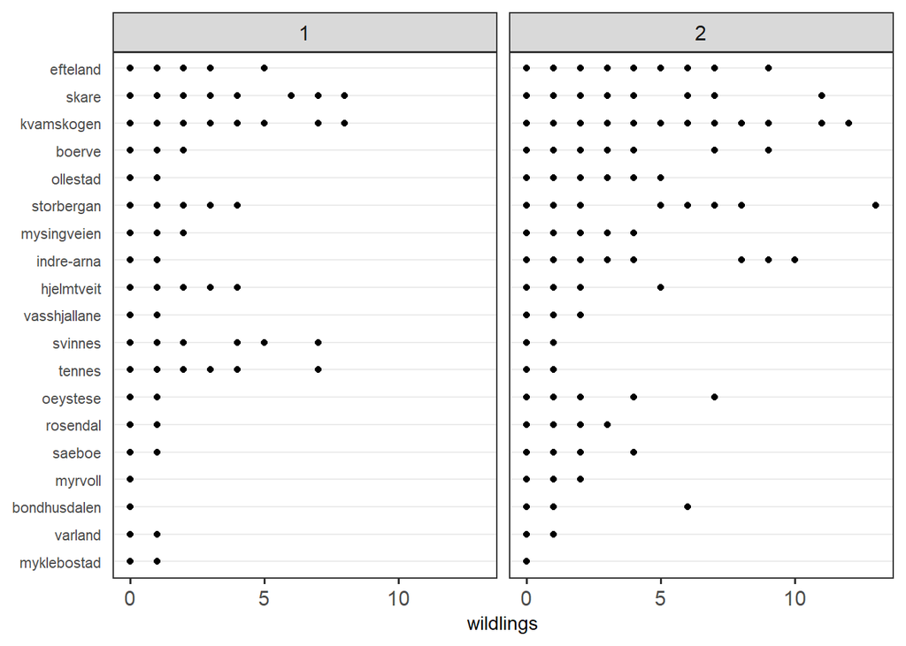

```r
bind_rows(dat, .id = "hgtclass") %>%
  ggplot(aes(wildlings, fct_reorder(locality, wildlings, mean))) +
         geom_point() + theme_dotplot + facet_grid(cols = vars(hgtclass))
```

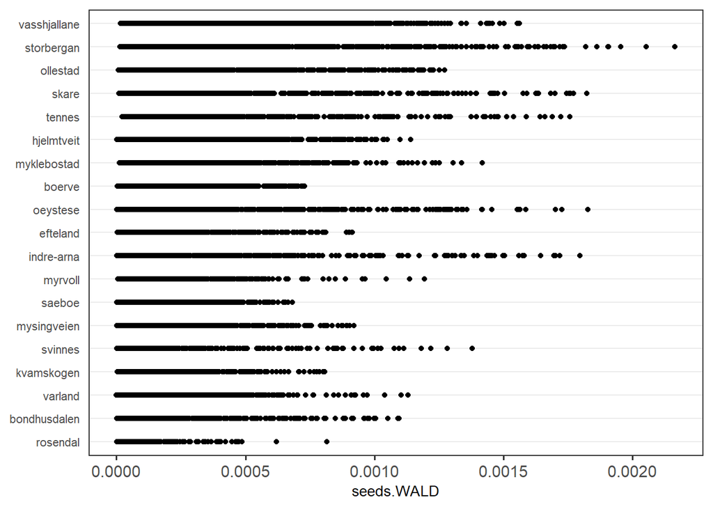

```r
ggplot(dat[[2]], aes(seeds.WALD, fct_reorder(locality, seeds.WALD, mean))) + geom_point() + theme_dotplot
```

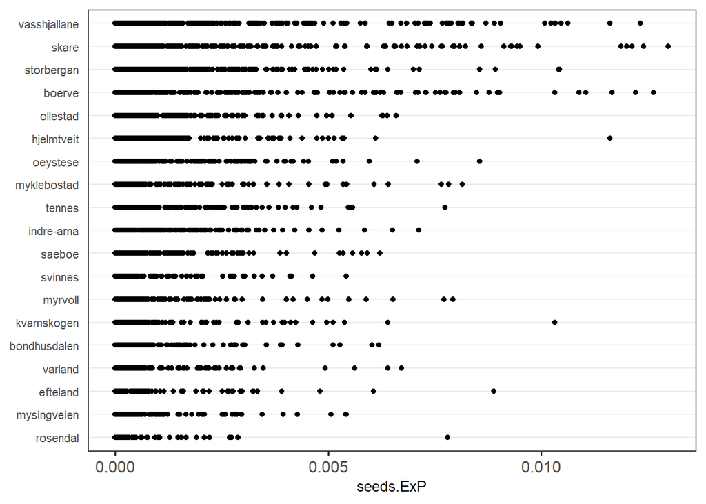

```r
ggplot(dat[[2]], aes(seeds.ExP, fct_reorder(locality, seeds.ExP, mean))) + geom_point() + theme_dotplot
```

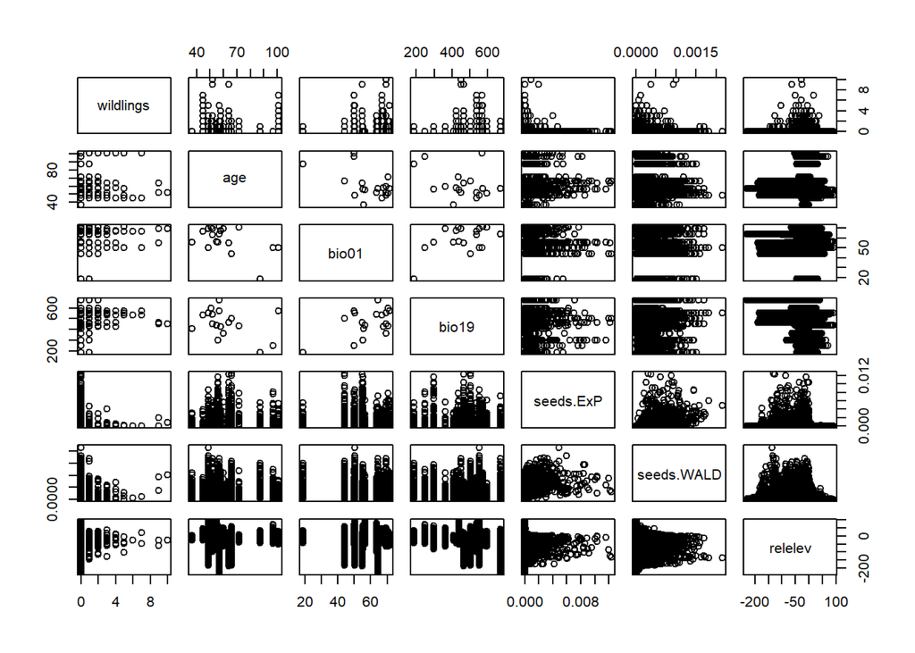

```r
pairs(dat[[2]][sample(nrow(dat[[2]]), 1e4), nottypes])
```

# P.sitchensis-lutzii

```r
IVi <- filter(IV, species == "P.sitchensis-lutzii") %>%
  remove_zero_cols()
DVi <- filter(DV, species == "P.sitchensis-lutzii")
dat <- DVi %>%
  group_split(hgtclass) %>%
  map(~ add_wildlings(IVi, .) %>%
        st_drop_geometry())
```

‘wildlings’ below are those in height class 2.

```
## temporary images written to 'C:\tmp'
```

### Data Frame Summary

#### dat

**Dimensions:** 87442 x 44  
**Duplicates:** 0

| No | Variable | Stats / Values | Freqs (% of Valid) | Graph | Missing |
| --- | --- | --- | --- | --- | --- |
| 1 | species [character] | 1. P.sitchensis-lutzii | 87442 (100.0%) |  | 0 (0.0%) |
| 2 | wildlings [numeric] | Mean (sd) : 0.2 (2.1) min < med < max: 0 < 0 < 206 IQR (CV) : 0 (12.6) | 67 distinct values |  | 0 (0.0%) |
| 3 | locality [character] | 1. sandve 2. harteigen 3. kausland 4. haakoeya 5. kvia 6. oevre-manger 7. fjoesne 8. langvassfjellet 9. roeynaasen 10. veggjaberget [ 32 others ] | 2498 ( 2.9%) 2497 ( 2.9%) 2472 ( 2.8%) 2458 ( 2.8%) 2452 ( 2.8%) 2428 ( 2.8%) 2427 ( 2.8%) 2413 ( 2.8%) 2383 ( 2.7%) 2378 ( 2.7%) 63036 (72.1%) |  | 0 (0.0%) |
| 4 | age [numeric] | Mean (sd) : 47.8 (12.6) min < med < max: 26 < 49 < 78 IQR (CV) : 17 (0.3) | 31 distinct values |  | 0 (0.0%) |
| 5 | bio01 [numeric] | Mean (sd) : 63.7 (13) min < med < max: 31.6 < 61.1 < 80.8 IQR (CV) : 23.9 (0.2) | 42 distinct values |  | 0 (0.0%) |
| 6 | bio19 [numeric] | Mean (sd) : 423.1 (72.6) min < med < max: 279 < 415 < 601 IQR (CV) : 109 (0.2) | 39 distinct values |  | 0 (0.0%) |
| 7 | seeds.ExP [numeric] | Mean (sd) : 0 (0) min < med < max: 0 < 0 < 0 IQR (CV) : 0 (5) | 87442 distinct values |  | 0 (0.0%) |
| 8 | seeds.WALD [numeric] | Mean (sd) : 0 (0) min < med < max: 0 < 0 < 0 IQR (CV) : 0 (2) | 87387 distinct values |  | 0 (0.0%) |
| 9 | relelev [numeric] | Mean (sd) : -13.1 (27.4) min < med < max: -110.6 < -10.7 < 216.9 IQR (CV) : 24.6 (-2.1) | 87233 distinct values |  | 0 (0.0%) |
| 10 | plantation forest [numeric] | Mean (sd) : 0 (0) min < med < max: 0 < 0 < 1 IQR (CV) : 0 (20.4) | 265 distinct values |  | 0 (0.0%) |
| 11 | T44 [numeric] | Mean (sd) : 0 (0.1) min < med < max: 0 < 0 < 1 IQR (CV) : 0 (7.1) | 381 distinct values |  | 0 (0.0%) |
| 12 | artificial [numeric] | Mean (sd) : 0.1 (0.2) min < med < max: 0 < 0 < 1 IQR (CV) : 0 (3.5) | 996 distinct values |  | 0 (0.0%) |
| 13 | T45 [numeric] | Mean (sd) : 0.2 (0.4) min < med < max: 0 < 0 < 1 IQR (CV) : 0 (1.9) | 996 distinct values |  | 0 (0.0%) |
| 14 | T32 [numeric] | Mean (sd) : 0.1 (0.3) min < med < max: 0 < 0 < 1 IQR (CV) : 0 (2.8) | 982 distinct values |  | 0 (0.0%) |
| 15 | V9 [numeric] | Mean (sd) : 0 (0.1) min < med < max: 0 < 0 < 1 IQR (CV) : 0 (6.8) | 629 distinct values |  | 0 (0.0%) |
| 16 | T34 [numeric] | Mean (sd) : 0.2 (0.3) min < med < max: 0 < 0 < 1 IQR (CV) : 0 (2.2) | 990 distinct values |  | 0 (0.0%) |
| 17 | V12 [numeric] | Mean (sd) : 0 (0) min < med < max: 0 < 0 < 1 IQR (CV) : 0 (41.3) | 53 distinct values |  | 0 (0.0%) |
| 18 | V1 [numeric] | Mean (sd) : 0.1 (0.2) min < med < max: 0 < 0 < 1 IQR (CV) : 0 (2.9) | 961 distinct values |  | 0 (0.0%) |
| 19 | T13 [numeric] | Mean (sd) : 0 (0) min < med < max: 0 < 0 < 1 IQR (CV) : 0 (25.5) | 109 distinct values |  | 0 (0.0%) |
| 20 | T4 [numeric] | Mean (sd) : 0.2 (0.3) min < med < max: 0 < 0 < 1 IQR (CV) : 0 (2.2) | 995 distinct values |  | 0 (0.0%) |
| 21 | T41 [numeric] | Mean (sd) : 0 (0.1) min < med < max: 0 < 0 < 1 IQR (CV) : 0 (6.6) | 547 distinct values |  | 0 (0.0%) |
| 22 | T1 [numeric] | Mean (sd) : 0 (0.1) min < med < max: 0 < 0 < 1 IQR (CV) : 0 (3.3) | 660 distinct values |  | 0 (0.0%) |
| 23 | V2 [numeric] | Mean (sd) : 0 (0.1) min < med < max: 0 < 0 < 1 IQR (CV) : 0 (6.4) | 650 distinct values |  | 0 (0.0%) |
| 24 | T2 [numeric] | Mean (sd) : 0 (0.1) min < med < max: 0 < 0 < 1 IQR (CV) : 0 (5.5) | 647 distinct values |  | 0 (0.0%) |
| 25 | T40 [numeric] | Mean (sd) : 0 (0.1) min < med < max: 0 < 0 < 1 IQR (CV) : 0 (12.7) | 415 distinct values |  | 0 (0.0%) |
| 26 | T42 [numeric] | Mean (sd) : 0 (0) min < med < max: 0 < 0 < 0.5 IQR (CV) : 0 (45.4) | 45 distinct values |  | 0 (0.0%) |
| 27 | V10 [numeric] | Mean (sd) : 0 (0.1) min < med < max: 0 < 0 < 1 IQR (CV) : 0 (15) | 217 distinct values |  | 0 (0.0%) |
| 28 | T18 [numeric] | Mean (sd) : 0 (0) min < med < max: 0 < 0 < 1 IQR (CV) : 0 (54.6) | 47 distinct values |  | 0 (0.0%) |
| 29 | T27 [numeric] | Mean (sd) : 0 (0.1) min < med < max: 0 < 0 < 1 IQR (CV) : 0 (7.8) | 274 distinct values |  | 0 (0.0%) |
| 30 | T17 [numeric] | Mean (sd) : 0 (0) min < med < max: 0 < 0 < 1 IQR (CV) : 0 (60.8) | 26 distinct values |  | 0 (0.0%) |
| 31 | T29 [numeric] | Mean (sd) : 0 (0) min < med < max: 0 < 0 < 1 IQR (CV) : 0 (25.5) | 108 distinct values |  | 0 (0.0%) |
| 32 | T16 [numeric] | Mean (sd) : 0 (0) min < med < max: 0 < 0 < 1 IQR (CV) : 0 (21.9) | 182 distinct values |  | 0 (0.0%) |
| 33 | V8 [numeric] | Mean (sd) : 0 (0) min < med < max: 0 < 0 < 0.9 IQR (CV) : 0 (111.6) | 14 distinct values |  | 0 (0.0%) |
| 34 | T31 [numeric] | Mean (sd) : 0 (0.2) min < med < max: 0 < 0 < 1 IQR (CV) : 0 (4.9) | 733 distinct values |  | 0 (0.0%) |
| 35 | V4 [numeric] | Mean (sd) : 0 (0) min < med < max: 0 < 0 < 0.5 IQR (CV) : 0 (17.1) | 105 distinct values |  | 0 (0.0%) |
| 36 | V3 [numeric] | Mean (sd) : 0 (0.1) min < med < max: 0 < 0 < 1 IQR (CV) : 0 (5.6) | 701 distinct values |  | 0 (0.0%) |
| 37 | T6 [numeric] | Mean (sd) : 0 (0.1) min < med < max: 0 < 0 < 1 IQR (CV) : 0 (13.6) | 353 distinct values |  | 0 (0.0%) |
| 38 | V13 [numeric] | Mean (sd) : 0 (0) min < med < max: 0 < 0 < 1 IQR (CV) : 0 (43.7) | 50 distinct values |  | 0 (0.0%) |
| 39 | T12 [numeric] | Mean (sd) : 0 (0) min < med < max: 0 < 0 < 1 IQR (CV) : 0 (19.3) | 187 distinct values |  | 0 (0.0%) |
| 40 | T24 [numeric] | Mean (sd) : 0 (0) min < med < max: 0 < 0 < 0.5 IQR (CV) : 0 (22.9) | 130 distinct values |  | 0 (0.0%) |
| 41 | T3 [numeric] | Mean (sd) : 0 (0) min < med < max: 0 < 0 < 1 IQR (CV) : 0 (57.1) | 29 distinct values |  | 0 (0.0%) |
| 42 | T21 [numeric] | Mean (sd) : 0 (0) min < med < max: 0 < 0 < 1 IQR (CV) : 0 (33.9) | 86 distinct values |  | 0 (0.0%) |
| 43 | T36 [numeric] | Mean (sd) : 0 (0) min < med < max: 0 < 0 < 1 IQR (CV) : 0 (22.4) | 104 distinct values |  | 0 (0.0%) |
| 44 | T33 [numeric] | Mean (sd) : 0 (0) min < med < max: 0 < 0 < 1 IQR (CV) : 0 (30.8) | 120 distinct values |  | 0 (0.0%) |

‘wildlings’ by height class and locality.

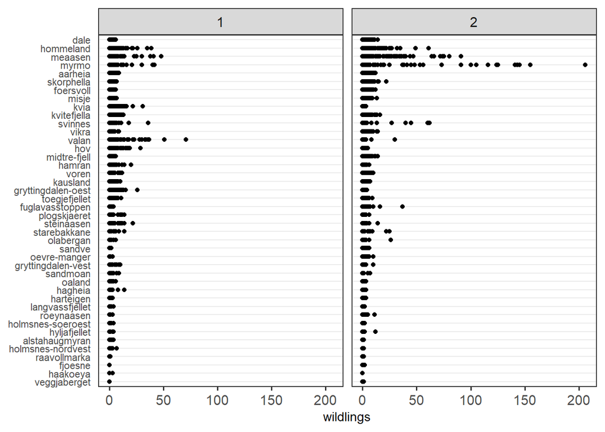

```r
bind_rows(dat, .id = "hgtclass") %>%
  ggplot(aes(wildlings, fct_reorder(locality, wildlings, mean))) +
         geom_point() + theme_dotplot + facet_grid(cols = vars(hgtclass))
```

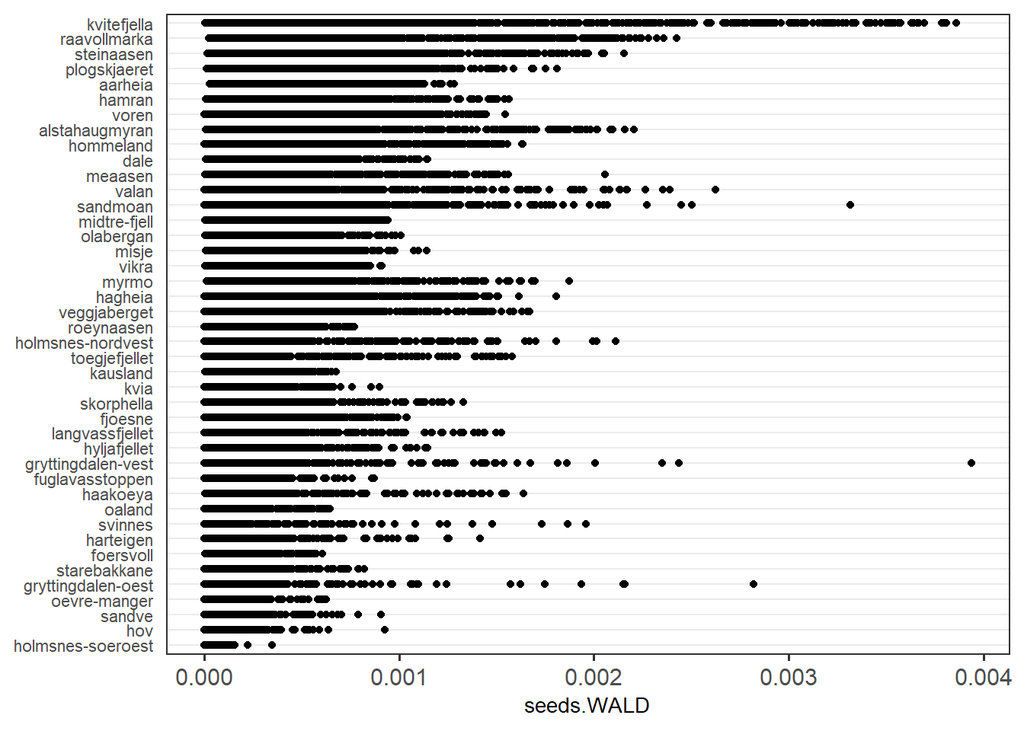

```r
ggplot(dat[[2]], aes(seeds.WALD, fct_reorder(locality, seeds.WALD, mean))) + geom_point() + theme_dotplot
```

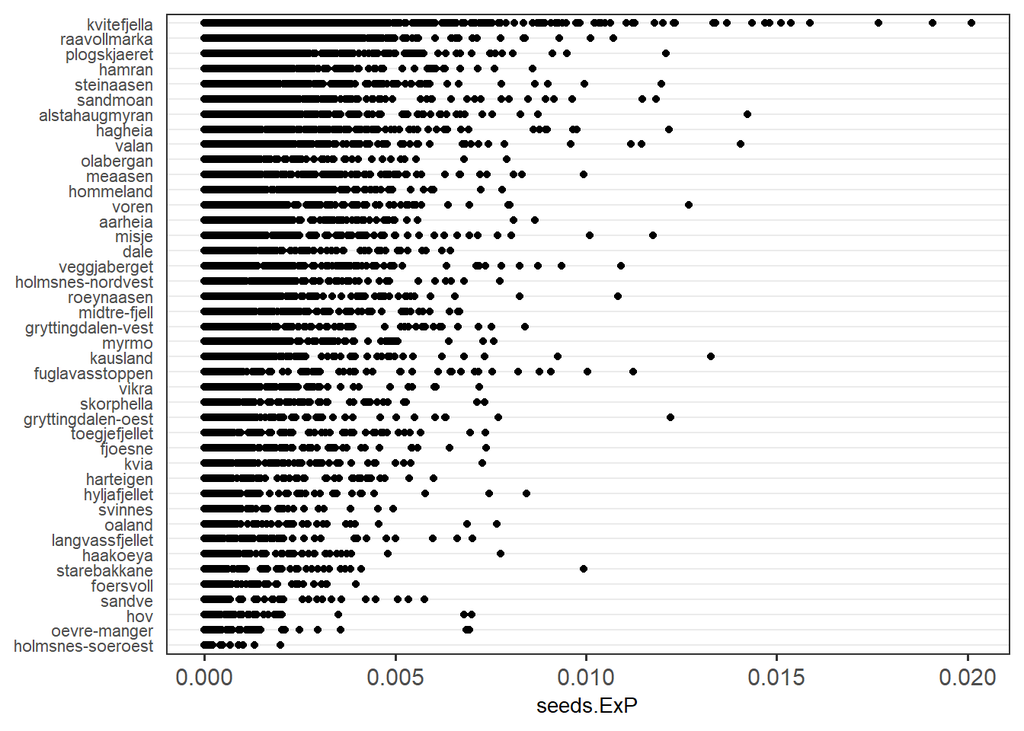

```r
ggplot(dat[[2]], aes(seeds.ExP, fct_reorder(locality, seeds.ExP, mean))) + geom_point() + theme_dotplot
```

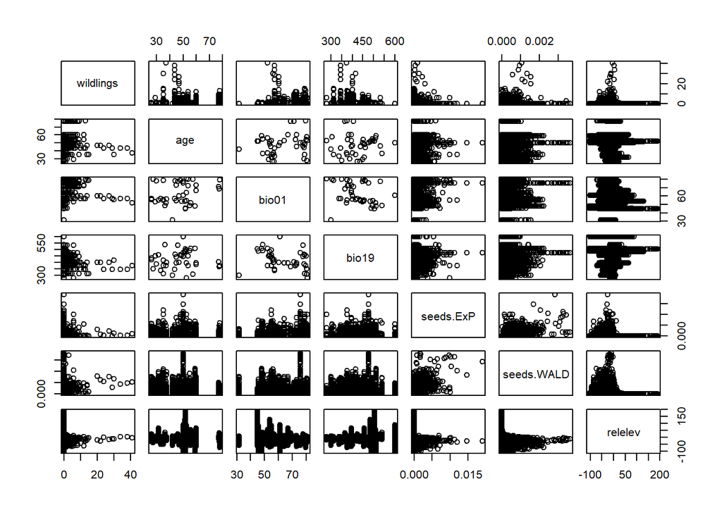

```r
pairs(dat[[2]][sample(nrow(dat[[2]]), 1e4), nottypes])
```